# Student Mental Stress

CHRISTINA THOMPSON ACQUAH

# 1 Introduction

College students face a wide range of academic and psychosocial pressures that can manifest as elevated levels of mental stress. In this project, we use a dataset of 760 undergraduates with 20 variables—both numerical (e.g. study hours, sleep duration) and categorical (e.g.gender, counseling attendance) to answer two practical questions:

Regression question: Which combination of academic, lifestyle, and personal factors best predicts the total number of stressors a student reports?

Classification question: Which combination of academic, lifestyle, and personal factors best distinguishes students who attend counseling from those who do not?

We will apply

CART regression to the numeric stress scores, and CART classification to the counseling attendance binary outcome,then compare their performance to traditional linear/logistic models.

## 1.1 Itemized List of Feature Variables

The table below presents the set of 17 core features we’ve chosen for our CART analyses of student mental stress and counseling attendance. Although the original survey recorded over 20 different items spanning academic, lifestyle, social, and psychological domains, we have focused on those variables most directly linked to stress levels and help‐seeking behavior. For each feature you’ll see its name, a concise description, and whether it’s treated as numerical or categorical serving as a handy reference before diving into the modeling steps.

```r
# Load knitr package for pretty table output
library(knitr)

# Define the feature variables with their descriptions and data types
features <- data.frame(
  Feature_Name = c(
    "Age",
    "Gender",
    "Academic Performance (GPA)",
    "Study Hours Per Week",
    "Social Media Usage (Hours per day)",
    "Sleep Duration (Hours per night)",
    "Physical Exercise (Hours per week)",
    "Family Support",
    "Financial Stress",
    "Peer Pressure",
    "Relationship Stress",
    "Diet Quality",
    "Stress Coping Mechanisms",
    "Cognitive Distortions",
    "Family Mental Health History",
    "Medical Condition",
    "Substance Use"
  ),
  Description = c(
    "Student's age in years",
    "Student's gender (Male/Female)",
    "Self‑reported GPA on a 0–4 scale",
    "Hours spent studying per week",
    "Hours per day spent on social media",
    "Average hours of sleep per night",
    "Hours of physical exercise per week",
    "Self‑rated family support (e.g. 1–5 scale)",
    "Self‑rated financial stress level (1–5)",
    "Self‑rated peer pressure level (1–5)",
    "Self‑rated relationship stress level (1–5)",
    "Self‑rated diet quality (1–5)",
    "Primary coping mechanism category (e.g. Exercise, Meditation)",
    "Score or count of cognitive distortions",
    "Presence of family mental health history (Yes/No)",
    "Presence of a medical condition (Yes/No)",
    "Frequency or count of substance use episodes"
  ),
  Data_Type = c(
    "Numerical",
    "Categorical",
    "Numerical",
    "Numerical",
    "Numerical",
    "Numerical",
    "Numerical",
    "Numerical",
    "Numerical",
    "Numerical",
    "Numerical",
    "Numerical",
    "Categorical",
    "Numerical",
    "Categorical",
    "Categorical",
    "Numerical"
  ),
  stringsAsFactors = FALSE
)

# Print the table using knitr::kable
kable(features)
```

| Feature_Name | Description | Data_Type |
| --- | --- | --- |
| Age | Student’s age in years | Numerical |
| Gender | Student’s gender (Male/Female) | Categorical |
| Academic Performance (GPA) | Self‑reported GPA on a 0–4 scale | Numerical |
| Study Hours Per Week | Hours spent studying per week | Numerical |
| Social Media Usage (Hours per day) | Hours per day spent on social media | Numerical |
| Sleep Duration (Hours per night) | Average hours of sleep per night | Numerical |
| Physical Exercise (Hours per week) | Hours of physical exercise per week | Numerical |
| Family Support | Self‑rated family support (e.g. 1–5 scale) | Numerical |
| Financial Stress | Self‑rated financial stress level (1–5) | Numerical |
| Peer Pressure | Self‑rated peer pressure level (1–5) | Numerical |
| Relationship Stress | Self‑rated relationship stress level (1–5) | Numerical |
| Diet Quality | Self‑rated diet quality (1–5) | Numerical |
| Stress Coping Mechanisms | Primary coping mechanism category (e.g. Exercise, Meditation) | Categorical |
| Cognitive Distortions | Score or count of cognitive distortions | Numerical |
| Family Mental Health History | Presence of family mental health history (Yes/No) | Categorical |
| Medical Condition | Presence of a medical condition (Yes/No) | Categorical |
| Substance Use | Frequency or count of substance use episodes | Numerical |

# 2 Data Preparation

## 2.1 Exploratory Data Analysis (EDA)

As we set out to understand what drives students’ stress and their likelihood of seeking counseling, our first task was simply to look at each variable on its own. We laid out a grid of histograms Age, GPA, Study Hours, Social‑Media Usage, Sleep Duration, Physical Exercise, and Mental Stress Level so we could see the shape of every measure before any modeling began.

Age spans 18 to 30, with a fairly even spread punctuated by small peaks around 24 and 30, our sample truly covers the full undergraduate (and beyond) spectrum.

Social‑Media Usage surprised us with a bump at 7–8 hours/day, underscoring how plugged‑in our students are.

Next, we overlaid boxplots to compare stress across groups:

By Counseling Attendance: students who did and did not seek counseling share a median stress of 5, again with similar spreads. In other words, raw stress level alone doesn’t fully explain who reaches out for help.

Taken together, these distributions reassure us that each predictor brings its own, moderately spread signal—no two variables mirror one another, and none suffer from extreme skew that demands urgent transformation. We now have the confidence to grow our CART trees—knowing that each split (say, isolating students who sleep fewer than six hours versus those who study more than 40 hours) will tap into a distinct facet of the student experience, and that our classification tree can separate counselor‑seekers from non‑seekers on unique combinations of these factors.

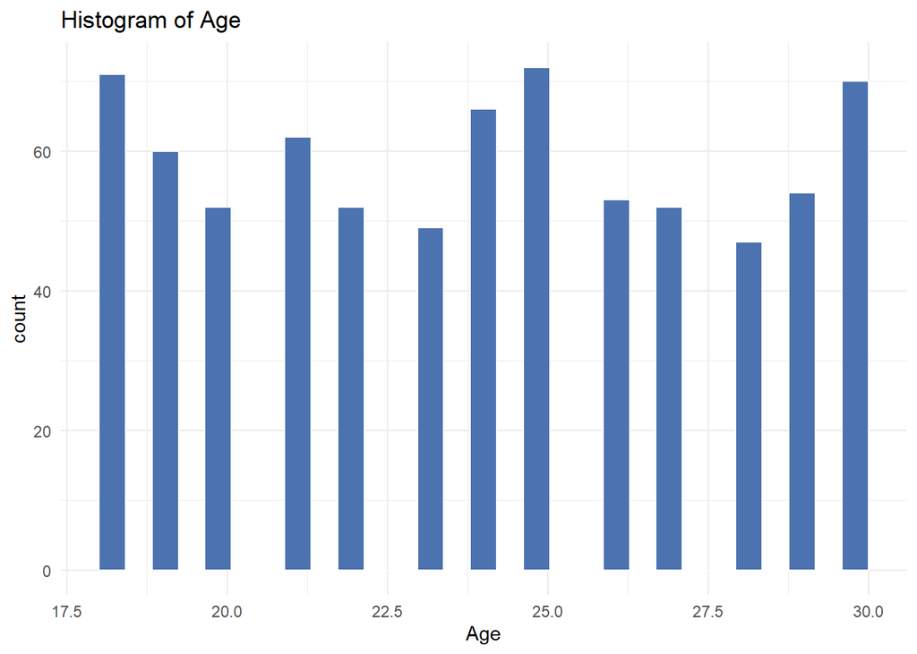

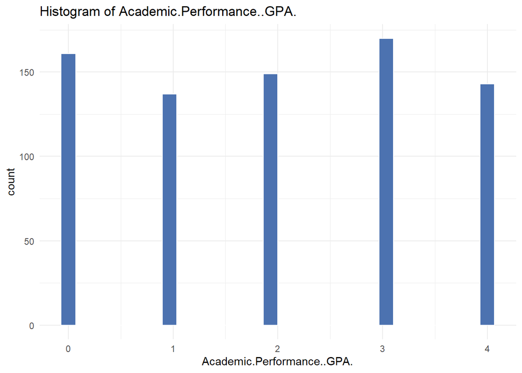

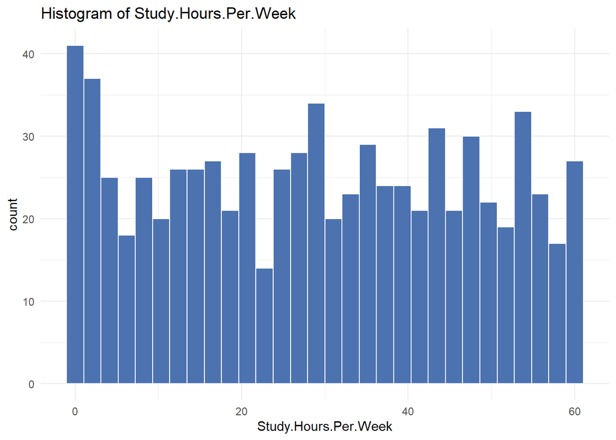

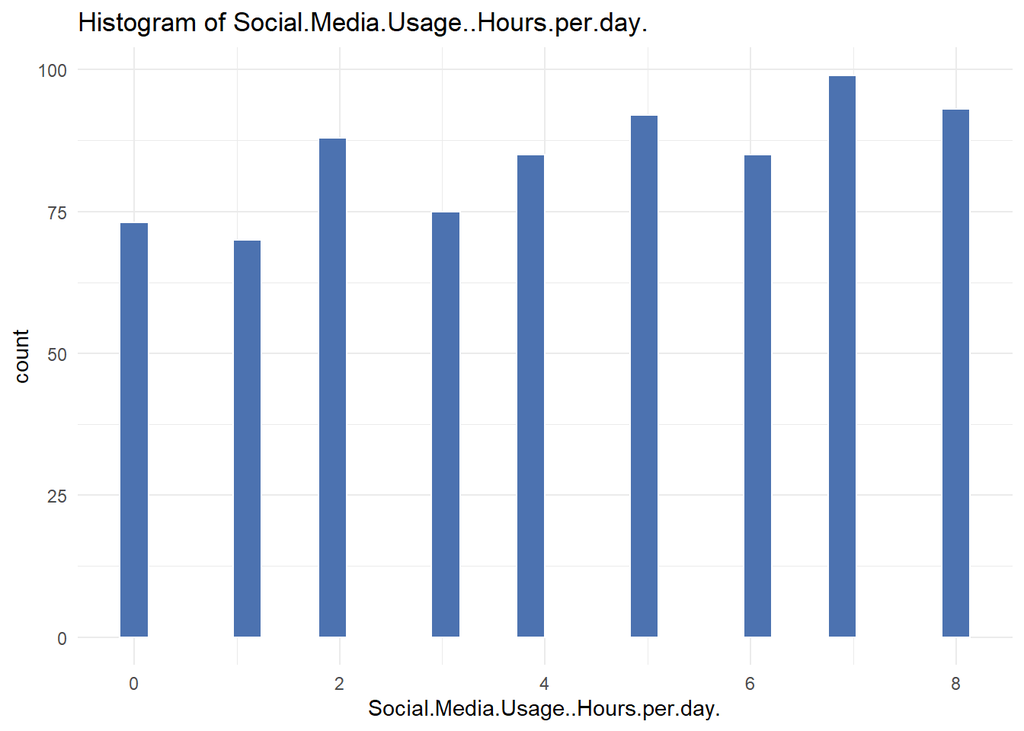

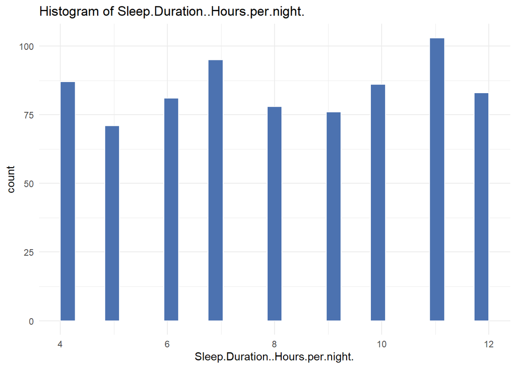

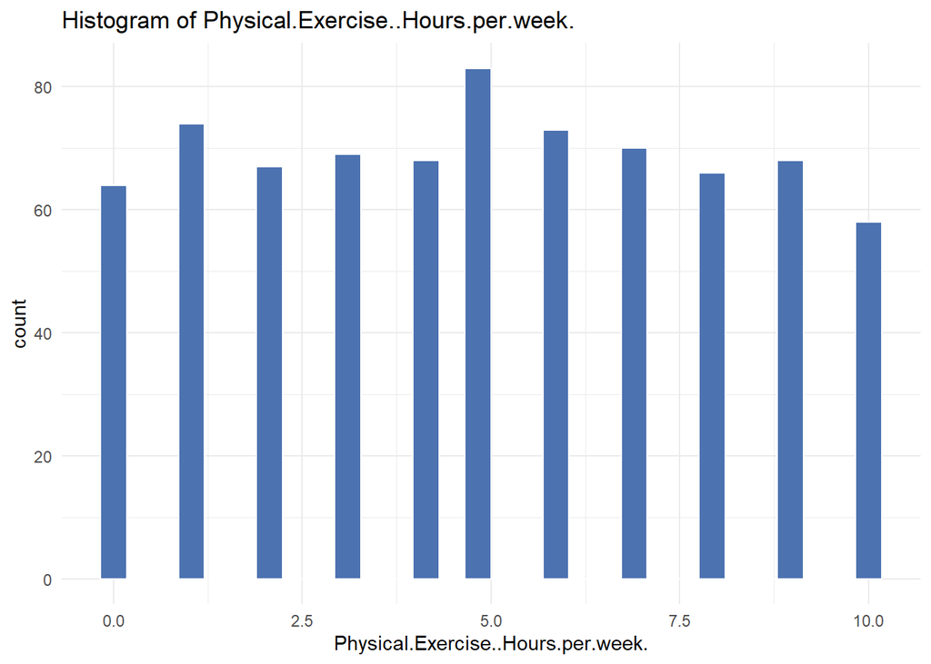

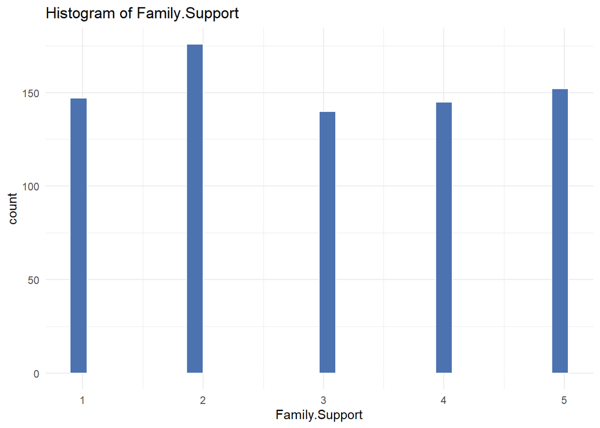

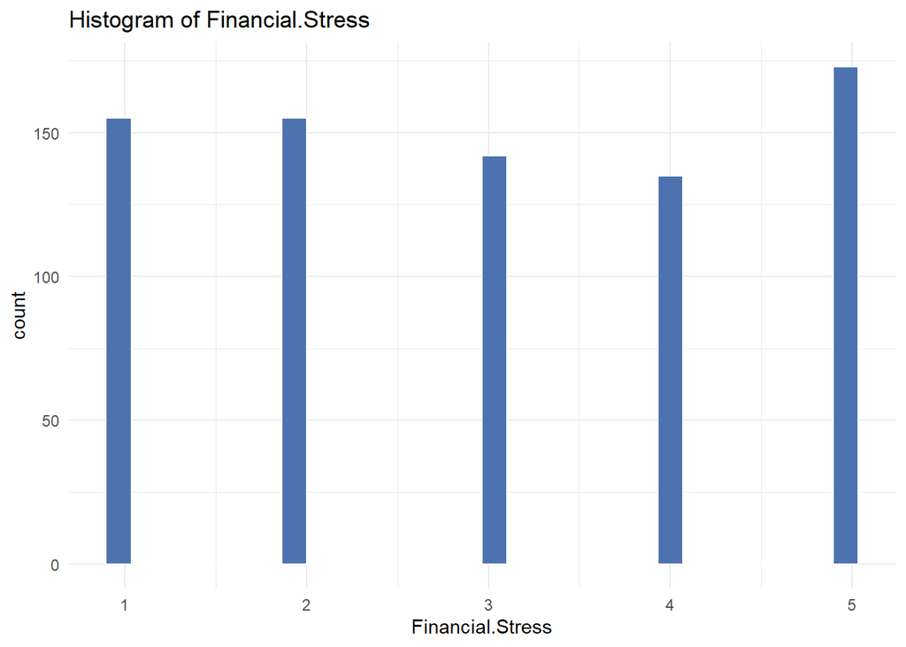

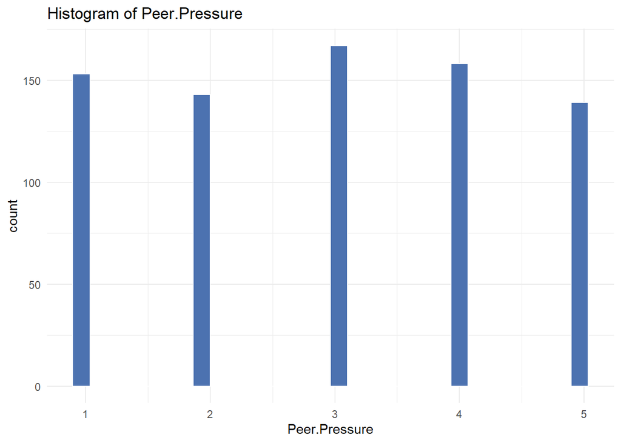

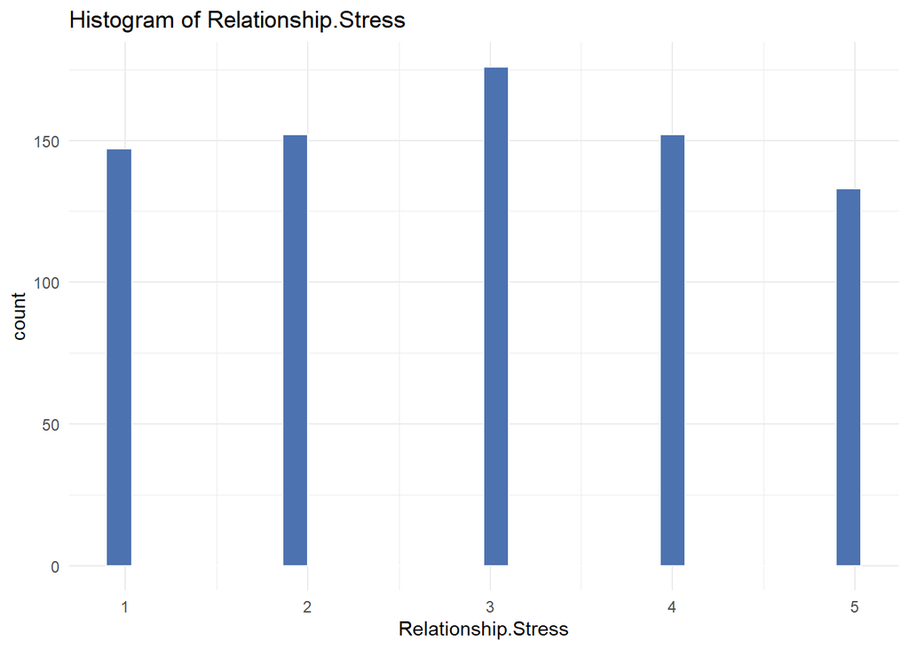

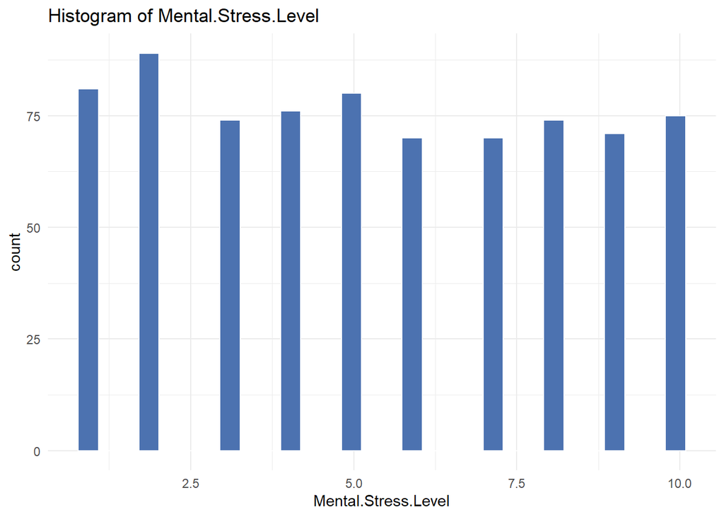

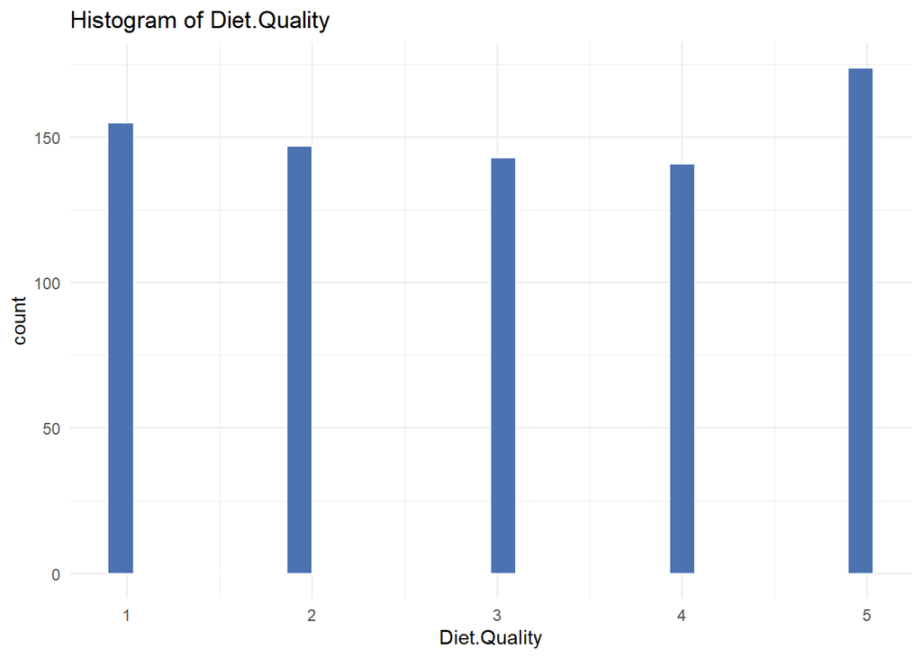

[2 more figures not shown]

```r
# Read the dataset
data_stress <- read.csv("https://christina-tinaa.github.io/Student_MentalHealth/Student_Mental_Stress.csv")
#summary(data_stress)

# 3.1 Clean up names & factor conversions
names(data_stress) <- make.names(names(data_stress))
data_stress <- data_stress %>%
  mutate(
    Gender                = factor(Gender),
    Counseling.Attendance = factor(Counseling.Attendance, levels = c("No","Yes"))
  )

# 3.2 Automatically detect numeric columns for histograms
numeric_vars <- names(data_stress)[sapply(data_stress, is.numeric)]

for (v in numeric_vars) {
  print(
    ggplot(data_stress, aes_string(x = v)) +
      geom_histogram(bins = 30, fill = "#4C72B0", color = "white") +
      labs(title = paste("Histogram of", v)) +
      theme_minimal()
  )
}
```

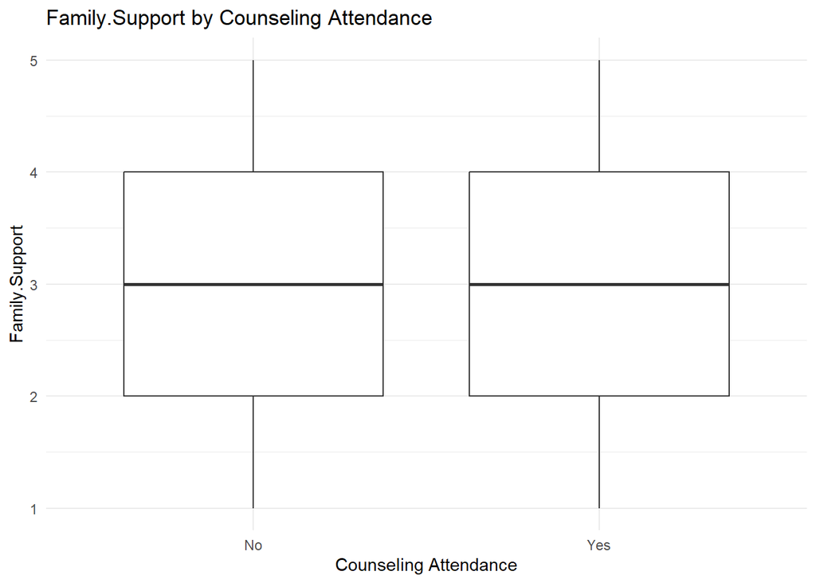

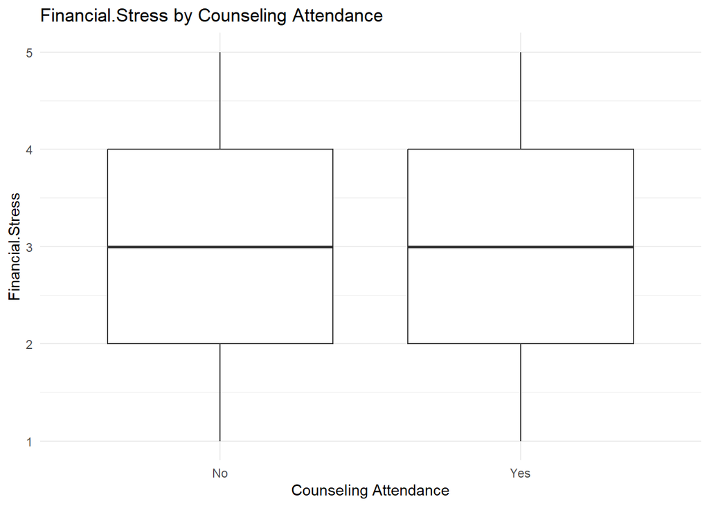

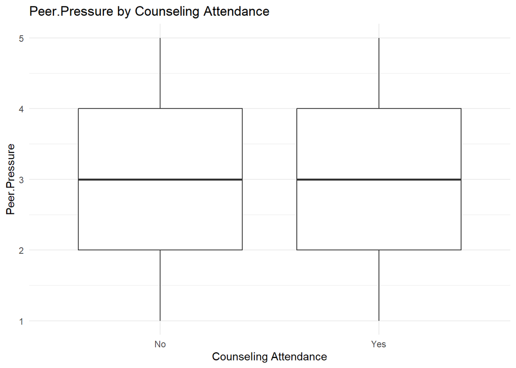

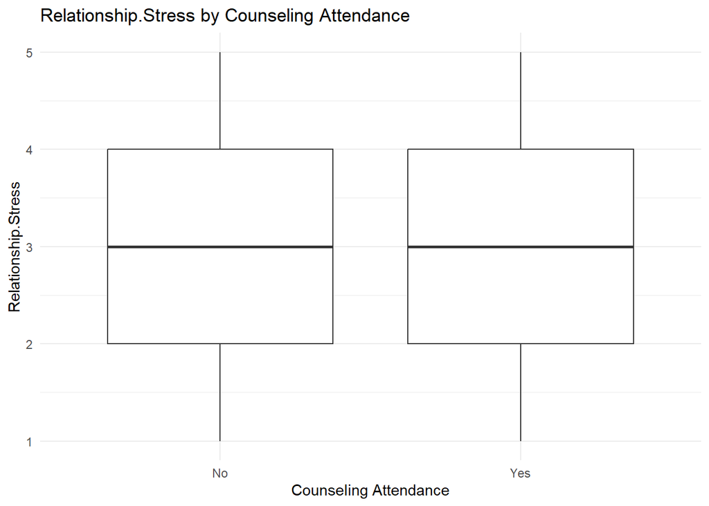

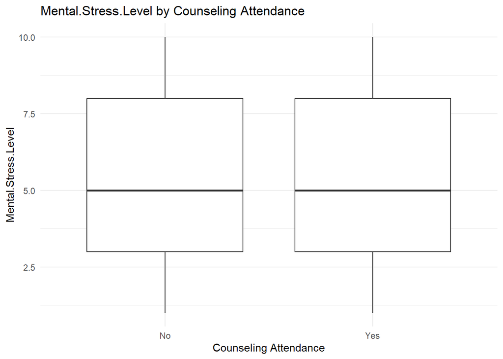

```r
# 3.3 Boxplots of key stress measures by Counseling.Attendance
stress_vars <- c(
  "Family.Support",
  "Financial.Stress",
  "Peer.Pressure",
  "Relationship.Stress",
  "Mental.Stress.Level"
)

for (v in stress_vars) {
  print(
    ggplot(data_stress, aes_string(x = "Counseling.Attendance", y = v)) +
      geom_boxplot() +
      labs(
        title = paste(v, "by Counseling Attendance"),
        x     = "Counseling Attendance",
        y     = v
      ) +
      theme_minimal()
  )
}
```

```r
# Feature Engineering
library(dplyr)
library(janitor)

# 1) Clean names, drop the ID column
data_stress <- data_stress %>%
  clean_names() %>%           # lower_snake_case
  select(-student_id)         # drop the ID

# 2) Feature engineering
data_stress <- data_stress %>%
  mutate(
    # 2a) Composite of stressor subscales
    total_stressors       = financial_stress + peer_pressure + relationship_stress,

    # 2b) Sleep quality categories
    sleep_quality         = case_when(
                              sleep_duration_hours_per_night >=  8 ~ "Good",
                              sleep_duration_hours_per_night >=  6 ~ "Moderate",
                              TRUE                                   ~ "Poor"
                            ) %>%
                            factor(levels = c("Poor","Moderate","Good")),

    # 2c) Social media usage buckets
    social_media_category = case_when(
                              social_media_usage_hours_per_day <= 1 ~ "Low",
                              social_media_usage_hours_per_day <= 3 ~ "Medium",
                              TRUE                                  ~ "High"
                            ) %>%
                            factor(levels = c("Low","Medium","High")),

    # 2d) Exercise level buckets
    exercise_level        = case_when(
                              physical_exercise_hours_per_week <  2 ~ "Low",
                              physical_exercise_hours_per_week <= 5 ~ "Medium",
                              TRUE                                   ~ "High"
                            ) %>%
                            factor(levels = c("Low","Medium","High")),

    # 2e) High‐GPA indicator
    high_gpa              = if_else(academic_performance_gpa >= 3.0, "Yes", "No") %>%
                            factor(levels = c("No","Yes")),

    # 2f) Log‐transform skewed study‐hours
    log_study_hours       = log1p(study_hours_per_week),

    # 2g) Interaction feature
    sleep_exercise        = sleep_duration_hours_per_night * physical_exercise_hours_per_week
  )

# 3) Quick sanity‐check
#glimpse(data_stress)
#summary(data_stress$total_stressors)
```